# Data visualisation of observational logging of studying at a desk at home

Project 4

## Am I a good student?

[figure not shown]

A GIF representing somebody clearing all their belongings off their desk with a pained look on their face

The focus of my observational logging data collection was trying to explore my study habits when studying at a desk at home.

## The nature of my data

I made 3 static graphs reflecting my study habits. I specified that the studying must be done at a desk and at home, because otherwise it could become subjective (for example, would sitting in a lecture theater count as studying at a desk?).

In terms of data collection, I started by observing the number of minutes to the nearest 10 minutes. Next, I wanted to measure what the most frequently studied paper was, so in the question I asked what paper I spent the most time on during this period of time. I often study more than one paper when studying so that’s why I specifically asked for the paper I spent the most time on.

I also asked what mode of learning I used primarily - paper or digital. I hardly ever use paper so most of the data showed that I learned digitally.

I added another question to the observational logging form, where if the responded responded with “digital” as the main learning mode, then I would ask whether it was “iPad” or “Laptop”. This is reflected in the second graph on this visual data story.

Altogether, this provided me with information about how long I study, what I study and how I study.

## What days do I have the most study sessions?

I decided to analyse the days of the week that I studied, and the total number of individual study sessions I have for each. *According to the data, I tend to study the most on Thursdays and Fridays.* This likely reflects when assignments are due. I study less on the weekend as I like to try and relax a bit. This graph is meaningful because I can use it to plan my week, by working out approximately how much work I should do on each day.

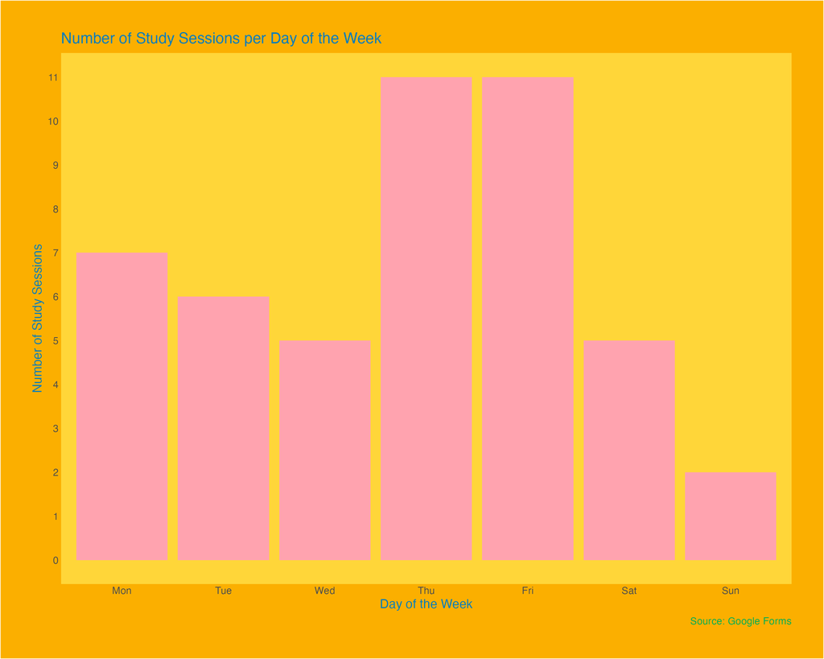

A vertical column chart comparing the number of study sessions per day of the week, with Thursday and Friday having the highest number of study sessions

## What percentage of my study sessions are primarily laptop-based?

I decided to compare what percentage my laptop was used while studying (compared to iPad or paper). *According to the graph, I use my laptop 70% of the time compared to non-laptop strategies at 30%.* This is meaningful because it is helping me work out how I study best so I can apply it in my next courses. Perhaps I could add a bit of diversity with how I study by doing less laptop study.

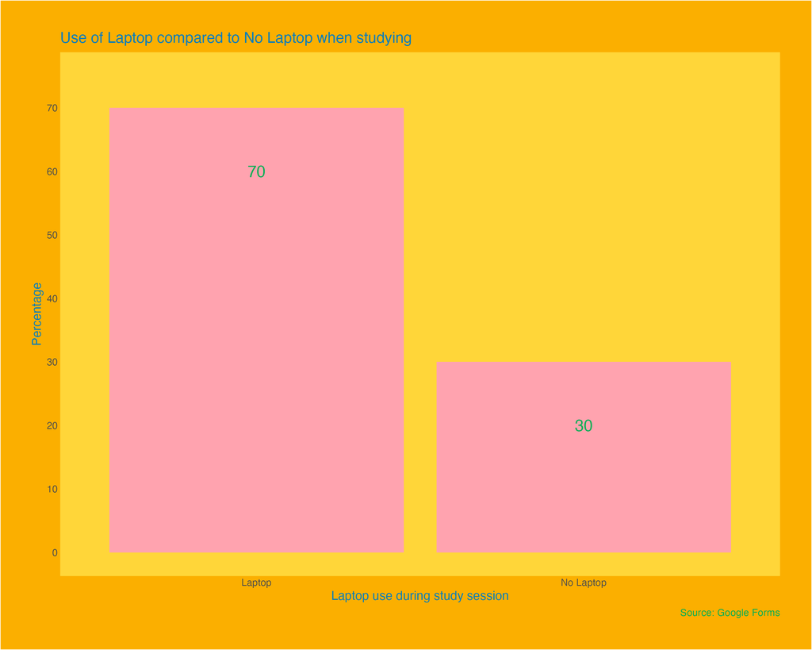

A bar graph comparing the percentage of study sessions using a laptop (70%) vs not using a laptop (30%). The bars are pink and the background is yellow with an orange border

## Do I study STATS or PSYCH papers for a longer time on average, when studying for longer periods of time?

I decided to compare STATS papers with PSYCH papers, to work out which I tend to study more, specifically when I am studying for extended periods of time (which is why I selected the 20 longest study sessions). *On average, I tend to have longer study sessions when studying STATS, with a mean duration at just over 100 minutes on average. This is compared to PSYCH papers which on average are studied for a mean of 90 minutes.* While a difference of 10-15 minutes may not seem meaningful, I think I have a short attention span so I tend to get distracted. However, when I am focused, I tend to enter a flow state and get lots of work done. This means that an extra 10 minutes can lead to meaningful differences within my work output. This is also meaningful because I can now set alarms before I start studying STATS so I remember to take regular breaks. It also means I shouldn’t study it when I am short on time, otherwise I might get distracted and spend too much time doing it.

I think this could be for 2 reasons:

1. STATS 220 is harder than all of my other psych papers, so I have to stick at things for longer. This is especially because my observational logging occurs in periods where the project is due (and projects require more work compared to no-project weeks)
2. I am biased, and remember that I have to do observational logging when doing STATS 220, and forget when studying psychology papers

Realistically, I think it’s definitely a mix of both!

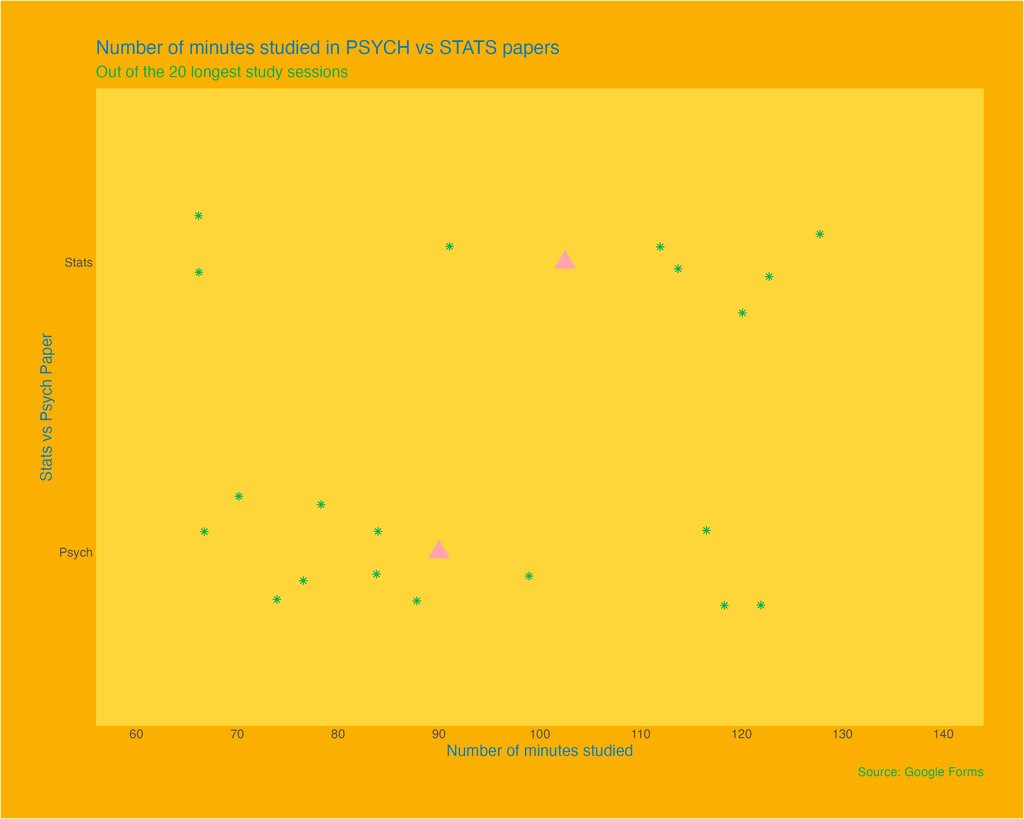

## Meme time

[figure not shown]

A humourous GIF comprised of 3 rotating graph frames with text above reading “my dreams after working on project 4:” to illustrate how it takes up this person’s internal thought processes